# Probability and Statistics

# Lab Assignment 1: Naive Bayes Classifier

### *Andrii Vandzhura, Dimitrii Yevchenko, Kateryna Akhynko*

## Introduction

During the past three weeks, you learned a couple of essential notions and theorems, and one of the most important among them is the *Bayes theorem*.

One of its applications is **Naive Bayes classifier**, which is a probabilistic classifier whose aim is to determine which class some observation probably belongs to by using the Bayes formula:
$$\mathsf{P}(\mathrm{class}\mid
\mathrm{observation})=\frac{\mathsf{P}(\mathrm{observation}\mid\mathrm{class})\mathsf{P}(\mathrm{class})}{\mathsf{P}
(\mathrm{observation})}$$

Under the strong independence assumption, one can calculate $\mathsf{P}(\mathrm{observation} \mid \mathrm{class})$ as
$$\mathsf{P}(\mathrm{observation}) =
\prod_{i=1}^{n} \mathsf{P}(\mathrm{feature}_i), \qquad
\mathsf{P}(\mathrm{observation} \mid \mathrm{class}) = \prod_{i=1}^{n}
\mathsf{P}(\mathrm{feature}_i \mid \mathrm{class}),$$
where $n$ is the total number of features describing a given observation. Thus, $\mathsf{P}(\mathrm{class}|\mathrm{observation})$ now can be calculated as

$$\mathsf{P}(\mathrm{class} \mid
\mathrm{\mathrm{observation}}) = \mathsf{P}(\mathrm{class})\times
\prod_{i=1}^{n}\frac{\mathsf{P}(\mathrm{feature}_i\mid
\mathrm{class})}{\mathsf{P}(\mathrm{feature}_i)}\tag{1}$$

All the terms on the right-hand side can be estimated from the data as respective relative frequencies;  
see [this site](https://monkeylearn.com/blog/practical-explanation-naive-bayes-classifier/) for more detailed explanations.

## Data description

There are 5 data sets uploaded on the cms.

To determine your variant, take your team number from the list of teams on cms and take *mod 5* - this is the number of your data set.

- **0 - authors** This data set consists of citations of three famous writers: Edgar Alan Poe, Mary Wollstonecraft Shelley and HP Lovecraft. The task with this data set is to classify a piece of text with the author who was more likely to write it.
- **1 - discrimination** This data set consists of tweets that have discriminatory (sexism or racism) messages or of tweets that are of neutral mood. The task is to determine whether a given tweet has discriminatory mood or does not.
- **2 - fake news** This data set contains data of American news: a headline and an abstract of the article. Each piece of news is classified as fake or credible. The task is to classify the news from test.csv as credible or fake.
- **3 - sentiment** All the text messages contained in this data set are labeled with three sentiments: positive, neutral or negative. The task is to classify some text message as the one of positive mood, negative or neutral.
- **4 - spam** This last data set contains SMS messages classified as spam or non-spam (ham in the data set). The task is to determine whether a given message is spam or non-spam.

Each data set consists of two files: *train.csv* and *test.csv*. The first one you will need find the probabilities distributions for each of the features, while the second one is needed for checking how well your classifier works. ### (Addition) We added additional library called MLmetrics in order to perform additional accuracy scoring And later we compare values of our own accuracy estimation to the F1 metric

```r
# here goes a list of recommended libraries,
# though you may install other ones if they are needed
library(tidytext)
library(readr)
library(dplyr)
```

```r
library(ggplot2)
library(MLmetrics)
```

## Instructions

- The first step is data pre-processing, which includes removing punctuation marks and stop words
- represent each message as a bag-of-words
- using the training set, calculate all the conditional probabilities in formula (1)
- use those to predict classes for messages in the test set
- evaluate effectiveness of the classifier by calculating the corresponding metrics
- shortly summarize your work
- do not forget to submit both the (compiled) Rmd source file and the .html output

### Data pre-processing

- Read the *.csv* data files.
- Сlear your data from punctuation or other unneeded symbols.
- Clear you data from stop words. You don’t want words as is, and, or etc. to affect your probabilities distributions, so it is a wise decision to get rid of them. Find list of stop words in the cms under the lab task.
- Represent each test message as its bag-of-words. Here: https://machinelearningmastery.com/gentle-introduction-bag-words-model/ you can find general introduction to the bag-of-words model and examples on to create it.
- It is highly recommended to get familiar with R data frames, it would make the work much easier to do.
- Useful links:
  - https://steviep42.github.io/webscraping/book/bagofwords.html#tidytext - example of using *tidytext* to count frequencies of the words.
  - Basics of Text Mining in R: http://rstudio-pubs-static.s3.amazonaws.com/256588_57b585da6c054349825cba46685d8464.html . Note that it also includes an example on how to create a bag of words from your text document.

### Reading csv

```r
train_path <- "train.csv"
test_path <- "test.csv"
train <- read.csv(file = train_path, stringsAsFactors = FALSE)
test <- read.csv(file = test_path, stringsAsFactors = FALSE)
```

# Removing punctuation and stop words

```r
stop_words_path <- "stop_words.txt"
stop_words <- read_file(stop_words_path)
splitted_stop_words <- strsplit(stop_words, split = '\n')
splitted_stop_words <- splitted_stop_words[[1]]
```

### Implementing and testing classifier

## Classifier implementation

The first we decided to implement classifier class, which is responsible for analising our data and predicting the credibility of certain piece of news

Implemented class fields: - data: all data - labels: array with fake and credible - fake_article_probability: probability of fake - credible_article_probability: probability of credible - all_vocabulary: data frame with all occurrences - fake_words_dictionary: data frame with fake words occurrences - credible_words_dictionary: data frame with credible words occurrences

Implemented class functions: - fit(X = data, Y = labels): creates all the useful data frames - probability_of_one_word(wordi, lable): calculates the probability of certain word to be credible or fake news - predict(message): predicts the credibility of certain news to be credible or fake based on Bayes’ formula - score(X_test): creates convenient data frame with predictions used for scoring effectiveness of model

```r
naiveBayes <- setRefClass("naiveBayes",
                          # here it would be wise to have some vars to store intermediate result
                          # frequency dict etc. Though pay attention to bag of wards!
                          fields = list(
                            data = "data.frame",                       # all data
                            labels = "vector",                         # array with fake and credible
                            fake_article_probability = "numeric",      # probability of fake
                            credible_article_probability = "numeric",  # probability of credible
                            all_vocabulary = "data.frame",             # dataframe with all occurences
                            fake_words_dictionary = "data.frame",      # dataframe with fake words occurences
                            credible_words_dictionary = "data.frame"   # dataframe with credible words occurences
                          ),

                          methods = list(
                            fit = function(X = data, Y = labels) {
                              tidy_text <- unnest_tokens(X, 'splitted', 'Body', token = "words") %>%
                                filter(!splitted %in% splitted_stop_words)

                              fake_article_probability <<- nrow(filter(train, Label == Y[2])) / nrow(X)
                              credible_article_probability <<- 1 - fake_article_probability

                              # all vocabulary
                              all_vocabulary <<- tidy_text %>% count(splitted, sort = TRUE)

                              # fake vocabulary
                              fake_words_dictionary <<- tidy_text[tidy_text$Label == Y[2],] %>% count(splitted, sort = TRUE) # creates {key : value}

                              # credible vocabulary
                              credible_words_dictionary <<- tidy_text[tidy_text$Label == Y[1],] %>% count(splitted, sort = TRUE)
                            },

                            probability_of_one_word = function(wordi, lable) {
                              lable_dictionary <- fake_words_dictionary
                              if (lable == "credible") {
                                lable_dictionary <- credible_words_dictionary
                              }
                              occurence <- lable_dictionary[lable_dictionary$splitted == wordi, "n"]  # amount of words
                              if (length(occurence) == 0) {
                                return(1 / (nrow(all_vocabulary) + nrow(lable_dictionary)))
                              }
                              else {
                                return((occurence + 1) / (nrow(all_vocabulary) + nrow(lable_dictionary)))
                              }
                            },

                            predict = function(message) {
                              result_for_fake <- fake_article_probability
                              result_for_credible <- credible_article_probability

                              multiplier <- 10000

                              message <- gsub('[[:punct:] ]+', ' ', message)
                              message <- casefold(message, upper = FALSE)
                              words <- strsplit(message, split = ' ')
                              words <- words[[1]]
                              words <- unlist(words)[!(unlist(words) %in% splitted_stop_words)]
                              for (word in words) {
                                result_for_fake <- result_for_fake *
                                  probability_of_one_word(word, lables[2]) * multiplier
                                result_for_credible <- result_for_credible *
                                  probability_of_one_word(word, lables[1]) * multiplier
                              }

                              if (result_for_fake > result_for_credible) {
                                return ("fake")
                              } else {
                                return ("credible")
                              }
                            },

                            score = function (X_test) {
                              X_test["prediction"] <- apply(X_test['Body'],1, FUN = model$predict)
                              return (X_test)
                            }

                          )
)
```

## Accuracy estimation

Estimates accuracy of the model based on the given DF. In model_accuracy function we calculate it by comparing values of two columns on each row. (~81,8%) In F1_scoring function we calculate the accuracy using F1 scoring method (importing library for that (~85%)

```r
model_accuracy <- function(dataframe) {
  correct_predictions <- 0
  articles_amount <- nrow(dataframe)

  for (i in 1:articles_amount) {
    actual_value <- dataframe$Label[i]
    predicted_value <- dataframe$prediction[i]
    if (actual_value == predicted_value) {
      correct_predictions <- correct_predictions + 1
    }
  }

  accuracy_value <- correct_predictions / articles_amount
  return(accuracy_value)
}

F1_scoring <- function (dataframe){
  actual <- dataframe$Label
  predicted <- dataframe$prediction

  print(F1_Score(predicted,actual))
}
```

## Estimating accuracy of classifier

We create Object of Class Naive Bayes, also creating some additional data. We ran method Score to get info about credibility for each article.

```r
lables <- unique(train$Label)
model <- naiveBayes(data = train, labels = unique(train$Label))
model$fit()
result <- model$score(test)

print("Model accuracy")
```

```
## [1] "Model accuracy"
```

```r
print(model_accuracy(result))  # ~81,8%
```

```
## [1] 0.8179551
```

```r
print(F1_scoring(result))      # ~85%
```

```
## [1] 0.8497942
## [1] 0.8497942
```

### Getting errors of classifier prediction

## Fake news classified as credible

In this section we create data frame with all the articles, where our implementation of classifier Failed. (fake - credible)

```r
error_in_fake_analysis <- function(dataframe) {
  error_in_credible <- dataframe[dataframe$Label == "fake",]
  error_in_credible2 <- error_in_credible[error_in_credible$prediction == "credible",]

  return (error_in_credible2)
}
error_in_fake <- error_in_fake_analysis(result)
```

## Credible news classified as fake

```r
error_in_credible_analysis <- function(dataframe) {
  error_in_credible <- dataframe[dataframe$Label == "credible",]
  error_in_credible2 <- error_in_credible[error_in_credible$prediction == "fake",]

  return (error_in_credible2)
}
error_in_credible <- error_in_credible_analysis(result)  # dataframe with (fake - credible)
```

## Diagrams realization

Function create_diagrams is used to create diagrams (DATA Visualization) Arguments: num_fake: amount of fake news num_credible: amount of credible name_fake: name for piece of fake news name_credible: name for piece of credible news title: title of chart

```r
create_diagrams <- function(num_fake, num_credible, name_fake, name_credible, title) {
  # pie chart of true numbers of fake and credible articles

  first_column <- c(name_credible, name_fake)
  second_column <- c(num_credible, num_fake)
  df <- data.frame(first_column, second_column)

  df <- df %>%
    arrange(desc(first_column)) %>%
    mutate(prop = second_column / sum(df$second_column) * 100) %>%
    mutate(ypos = cumsum(prop)- 0.5*prop )

  pie_chart <-ggplot(df, aes(x="", y=prop, fill=first_column)) +
    geom_bar(stat="identity", width=3, color="white") +
    coord_polar("y", start=0) +
    theme_void() +
    theme(legend.title=element_blank(), legend.position="right", legend.text = element_text(size=12))+
    geom_text(aes(y = ypos, label = as.character(second_column)), color = "white", size=5) +
    scale_fill_brewer(palette="Set5") +
    ggtitle(title, ) +
    scale_fill_hue(l=45)
  pie_chart
}
```

## Diagrams creation

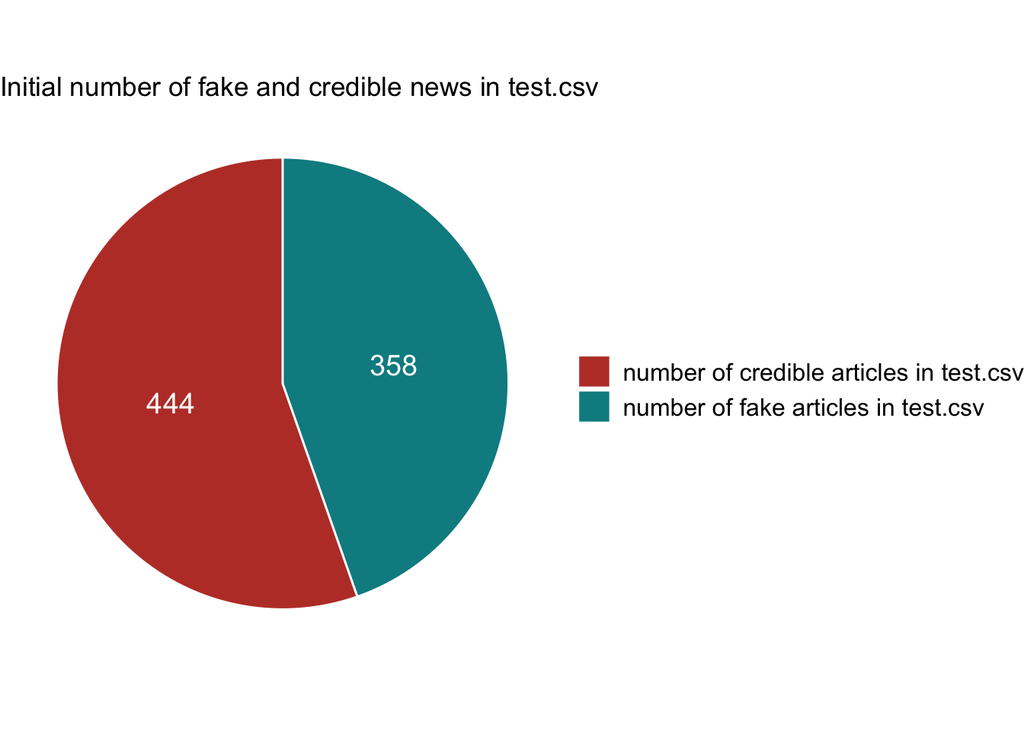

```r
num_fake_articles_test <- nrow(filter(test, Label == "fake"))
num_credible_articles_test <- nrow(filter(test, Label == "credible"))
names_initial_credible <- "number of credible articles in test.csv"
names_initial_fake <- "number of fake articles in test.csv"
initial_title <- "Initial number of fake and credible news in test.csv"
resulted_title <- "Number of fake and credible news according to Bayes Classifier"

fakes_amount <- nrow(result[result$prediction == "fake",])
credible_amount <- nrow(result[result$prediction == "credible",])

create_diagrams(num_fake_articles_test, num_credible_articles_test, names_initial_fake, names_initial_credible, initial_title)
```

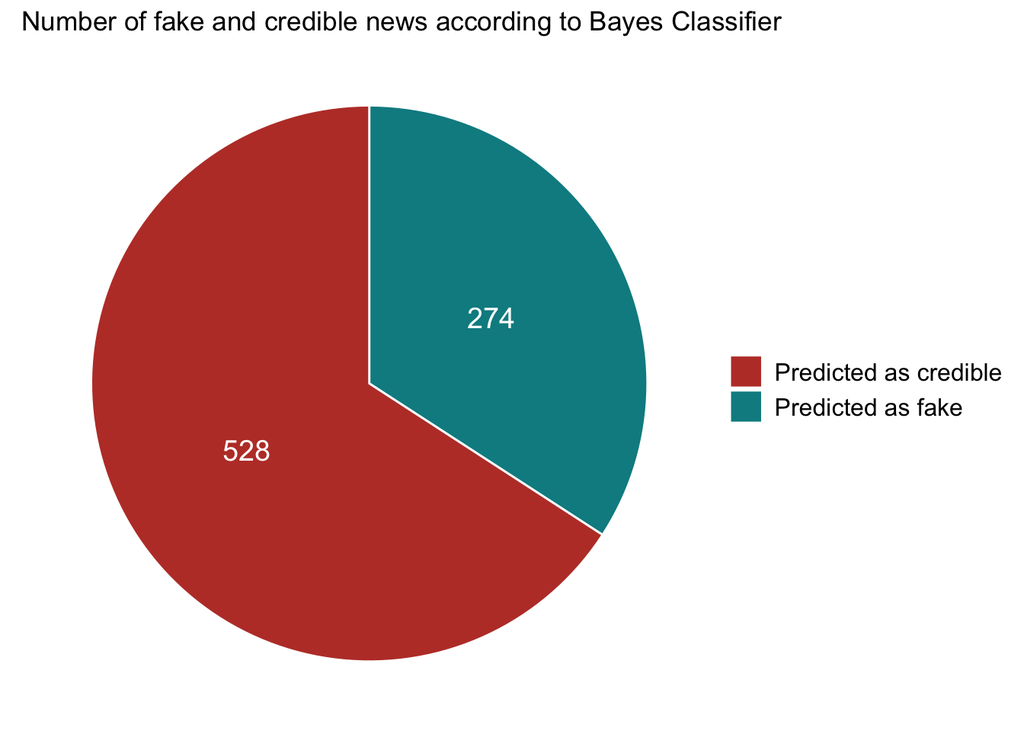

```r
create_diagrams(fakes_amount, credible_amount, "Predicted as fake", "Predicted as credible", resulted_title)
```

### Data visualization

Each time you work with some data, you need to understand it before you start processing it. R has very powerful tools to make nice plots and visualization. Show what are the most common words for negative and positive examples as a histogram, word cloud etc. Be creative!

## Classifier implementation

## Measure effectiveness of your classifier

- Note that accuracy is not always a good metric for your classifier. Look at precision and recall curves, F1 score metric.
- Visualize them.
- Show failure cases.

## Conclusion

- Describe the method implemented in general. Show what are mathematical foundations you are basing your solution on.
- List pros and cons of the method. This should include the limitations of your method, all the assumption you make about the nature of your data etc.

The Bayes classifier is based on the Bayes formula (a fundamental formula of probability theory). Considering each word as independent, it is necessary to multiply them for each specific message.

Bayes’ algorithm does not treat a sentence as a collection that has meaning.

P(word/Fake) = P(Fake/word) * P(Fake)/P(word)

P(Fake/word) = y + 1/ x + vocab , where y - occurrences of our word in fake set, y - set of all words in fake news, vocab - set of all words in our data set.

We have P(word) but we don’t count it in our program as for credible it would be the same denominator. To count probability for article we multiply all these conditional probabilities (as we consider them independent) Bayes works with each word separately, treating it as an independent part of the set. This algorithm is accurate, but has some drawbacks. The science of natural language processing can provide many examples of the incorrectness of Bayes’ theorem. If we consider each word as independent, we avoid the connection between cognate words, the position of the word in the sentence, homonyms, synonyms, etc. We can also see that F1 score metric works better than the one introduced by us in the task Generally, our team was very excited doing this project. But the main problem for us was the usage of R language and environments connected to it. We actually knew the solution for this problem, but inconvenient syntax of R and of absence of structured guide for it, made the work 10 times longer. <3